# A "Tour de Package" - Supervised Machine Learning Packages in Python

**A Gentle Introduction to Building Models in Different Frameworks**

**Was run locally on**: Local, Macbook Pro, Processor: 2.8 GHz Intel Core i7; Memory: 16 GB 2133 MHz LPDDR3

**Python Version:** 3.5

**Was run on AWS**: AWS Deep Learning AMI, p2.xlarge (1 GPU)

**Skill Level:** Beginner to Intermediate

# Goals

1. Walk away with an understanding of how to build some basic models in scikit-learn and evaluate them.
2. Develop a familiarity of how H2O makes it easy to build a stacked ensemble.
3. Gain high level awareness of how to build neural networks in Keras.

[figure not shown]

**Side Goals**

- Gain high level understanding of:
- Vectorization
- Word Embeddings
- A few ML models: Naive Bayes, Support Vector Machine, Stacked Ensembles
- Two DL models: Concurrent Neural Networks and Recurrent Neural Networks

**What is not covered in this tutorial**  
While I'll touch at a high level on the general mechanics of these models, we could spent another week talking about the following in great detail.

- Mathematics on dot products, matrix factorization, kernel functions, and backpropogation.
- All the different types of evaluation metrics. Today we will use 'accuracy' of classification, 'mse', and 'log_loss'.
- Deep learning, in terms of explanining how a convolutional neural network completely works (i.e. convolution, pooling, activation, backprop), or recurrent neural networks.

# Let's get started!

**Set up**

Make a directory called `wids_tutorial` and in that directory, create a sub-directory called `data`. Download the Reviews.csv file and place it in the `data` folder. Download the other files from Github and install in the main `wids_tutorial` directory.

```python
import pandas as pd
import numpy as np
from datetime import datetime
import matplotlib.pyplot as plt
%matplotlib inline
```

```python
%%time
data = pd.read_csv("data/Reviews.csv")
print(data.shape)
print(data.dtypes)
```

```
(568454, 10)
Id                         int64
ProductId                 object
UserId                    object
ProfileName               object
HelpfulnessNumerator       int64
HelpfulnessDenominator     int64
Score                      int64
Time                       int64
Summary                   object
Text                      object
dtype: object
CPU times: user 3.22 s, sys: 299 ms, total: 3.52 s
Wall time: 3.53 s
```

```python
data.head()
```

|  | Id | ProductId | UserId | ProfileName | HelpfulnessNumerator | HelpfulnessDenominator | Score | Time | Summary | Text |
| --- | --- | --- | --- | --- | --- | --- | --- | --- | --- | --- |
| 0 | 1 | B001E4KFG0 | A3SGXH7AUHU8GW | delmartian | 1 | 1 | 5 | 1303862400 | Good Quality Dog Food | I have bought several of the Vitality canned d... |
| 1 | 2 | B00813GRG4 | A1D87F6ZCVE5NK | dll pa | 0 | 0 | 1 | 1346976000 | Not as Advertised | Product arrived labeled as Jumbo Salted Peanut... |
| 2 | 3 | B000LQOCH0 | ABXLMWJIXXAIN | Natalia Corres "Natalia Corres" | 1 | 1 | 4 | 1219017600 | "Delight" says it all | This is a confection that has been around a fe... |
| 3 | 4 | B000UA0QIQ | A395BORC6FGVXV | Karl | 3 | 3 | 2 | 1307923200 | Cough Medicine | If you are looking for the secret ingredient i... |
| 4 | 5 | B006K2ZZ7K | A1UQRSCLF8GW1T | Michael D. Bigham "M. Wassir" | 0 | 0 | 5 | 1350777600 | Great taffy | Great taffy at a great price. There was a wid... |

```python
#let's look at the first review
data.iloc[0, 9]
```

```
'I have bought several of the Vitality canned dog food products and have found them all to be of good quality. The product looks more like a stew than a processed meat and it smells better. My Labrador is finicky and she appreciates this product better than  most.'
```

```python
#let's look at the last review
data.iloc[568453, 9]
```

```
'I am very satisfied ,product is as advertised, I use it on cereal, with raw vinegar, and as a general sweetner.'
```

**Let's cut the dataset down just for this tutorial.** So that people with less powerful CPUs can run the tutorial.

```python
#For the purposes of the tutorial so that others can run this on their CPU, I'm going to cut this dataset in QUARTER

from __future__ import division
tenth = np.int(len(data)/10)
```

```python
#confirm 'half' is an integer which is required in order to slice the dataframe - float won't work
tenth
```

```
56845
```

```python
data_tu = data[:tenth]
print(data_tu.shape)
```

```
(56845, 10)
```

```python
data_tu.columns
```

```
Index(['Id', 'ProductId', 'UserId', 'ProfileName', 'HelpfulnessNumerator',
       'HelpfulnessDenominator', 'Score', 'Time', 'Summary', 'Text'],
      dtype='object')
```

```python
#export in case I need to reload again
#data_tu.to_csv("/Users/catherineordun/Documents/Data/data_quartered_wids.csv")
```

# Preprocessing

We will preprocess this data in three ways:

- Normalize the datetime
- As a part of each package to handle text, we will:
- - Use TFIDF Vectorizer in Scikit-learn
- - Tokenize and apply Word2Vec in H2O
- - Use TensorFlow to preprocess in Keras

    > > This bullet is wrong: In Keras we're going to tokenize using Keras's built in np.utility functions

```python
data_tu.shape
```

```
(56845, 10)
```

```python
data_tu.dtypes
```

```
Id                         int64
ProductId                 object
UserId                    object
ProfileName               object
HelpfulnessNumerator       int64
HelpfulnessDenominator     int64
Score                      int64
Time                       int64
Summary                   object
Text                      object
dtype: object
```

**Examine a few random comments**

```python
#the 10th comment
list(data_tu.iloc[9][['Text', 'Summary']])
```

```
['This is a very healthy dog food. Good for their digestion. Also good for small puppies. My dog eats her required amount at every feeding.',
 'Healthy Dog Food']
```

```python
#the last comment
list(data_tu.iloc[56844][['Text', 'Summary']])
```

```
["Love this chocolate! If you've ever tried to temper with the crappy chocolate you find at the grocery store, you will instantly be grateful for this stuff. It tempered on my first try and tasted wonderful! Definitely worth the money.",
 'Love love love this chocolate']
```

**Normalize the Datetime**

```python
#First let's look at the current dtype for the date
data_tu.dtypes
#We can see that 'Time' is currently an int64. We need to change this to datetime.
```

```
Id                         int64
ProductId                 object
UserId                    object
ProfileName               object
HelpfulnessNumerator       int64
HelpfulnessDenominator     int64
Score                      int64
Time                       int64
Summary                   object
Text                      object
dtype: object
```

```python
import datetime as datetime

#string format time to YY
data_tu['datetime'] = data_tu['Time'].map(lambda x: (datetime.datetime.fromtimestamp(int(x)).strftime('%Y-%m-%d')))
```

```python
#pandas conversion to datetime variable
data_tu['datetime'] = pd.to_datetime(data_tu['datetime'])
print(data_tu.dtypes)
```

```
Id                                 int64
ProductId                         object
UserId                            object
ProfileName                       object
HelpfulnessNumerator               int64
HelpfulnessDenominator             int64
Score                              int64
Time                               int64
Summary                           object
Text                              object
datetime                  datetime64[ns]
dtype: object
```

```python
data_tu.head(3)
```

|  | Id | ProductId | UserId | ProfileName | HelpfulnessNumerator | HelpfulnessDenominator | Score | Time | Summary | Text | datetime |
| --- | --- | --- | --- | --- | --- | --- | --- | --- | --- | --- | --- |
| 0 | 1 | B001E4KFG0 | A3SGXH7AUHU8GW | delmartian | 1 | 1 | 5 | 1303862400 | Good Quality Dog Food | I have bought several of the Vitality canned d... | 2011-04-26 |
| 1 | 2 | B00813GRG4 | A1D87F6ZCVE5NK | dll pa | 0 | 0 | 1 | 1346976000 | Not as Advertised | Product arrived labeled as Jumbo Salted Peanut... | 2012-09-06 |
| 2 | 3 | B000LQOCH0 | ABXLMWJIXXAIN | Natalia Corres "Natalia Corres" | 1 | 1 | 4 | 1219017600 | "Delight" says it all | This is a confection that has been around a fe... | 2008-08-17 |

```python
data_tu.dtypes
```

```
Id                                 int64
ProductId                         object
UserId                            object
ProfileName                       object
HelpfulnessNumerator               int64
HelpfulnessDenominator             int64
Score                              int64
Time                               int64
Summary                           object
Text                              object
datetime                  datetime64[ns]
dtype: object
```

# Basic EDA

```python
#run only if you want to install directly from Jupyter Notebook into your environment instead of pip install
#import sys
#!{sys.executable} -m pip install seaborn
```

```python
import seaborn as sns
```

**Average Number of Reviews by Year**

- Average Number of Reviews by Year
- Average Score per Year
- Average Annual Number of Reviews and Amazon Score
- Exploration of Low-Score Comments for a Product = Greenies

The majority of the reviews are in the year 2011 and 2012.

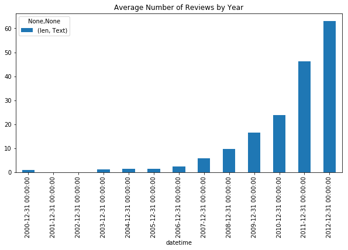

```python
reviews = (pd.pivot_table(data_tu,index=["datetime"],values=["Text"],aggfunc=[len])).resample('A').mean()
reviews.fillna(value=0, inplace=True)
reviews.plot(kind='bar', figsize=(10,5))
plt.title('Average Number of Reviews by Year')
plt.show()
```

**Average Review Score per Year**

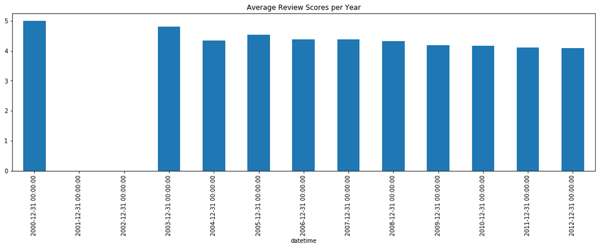

```python
#Amazon Score for all time
((data_tu.set_index('datetime')).resample('A').mean())['Score'].plot(kind='bar', figsize=(18,5))
plt.title('Average Review Scores per Year')
plt.show()
```

**Average Annual Number of Reviews and Amazon Score**

```python
reviews_and_scores = (pd.pivot_table(data_tu,index=["datetime"],
                       values=["Text", "Score"],
                       aggfunc={"Text": lambda x: len(x),
                               "Score": lambda x: x.mean()})).resample('A').mean()
```

The average Amazon Rating is still pretty positive (greater than 4) per year. But as the number of reviews have increased, the rating for products have declined.

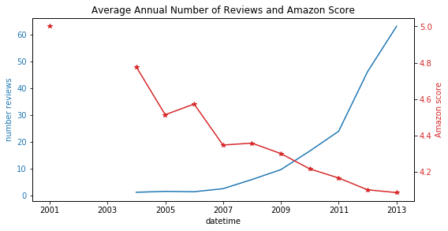

```python
t = (reviews_and_scores.reset_index())['datetime']
data1 = (reviews_and_scores.reset_index())['Text']
data2 = (reviews_and_scores.reset_index())['Score']

fig, ax1 = plt.subplots(figsize=(8,4))

color = 'tab:blue'
ax1.set_xlabel('datetime')
ax1.set_ylabel('number reviews', color=color)
ax1.plot(t, data1, color=color)
ax1.tick_params(axis='y', labelcolor=color)

ax2 = ax1.twinx()  # instantiate a second axes that shares the same x-axis

color = 'tab:red'
ax2.set_ylabel('Amazon score', color=color)  # we already handled the x-label with ax1
ax2.plot(t, data2, color=color, marker='*')
ax2.tick_params(axis='y', labelcolor=color)

fig.tight_layout()  # otherwise the right y-label is slightly clipped
plt.title('Average Annual Number of Reviews and Amazon Score')
plt.show()
```

```python
print("In this dataset, there is", data_tu['ProductId'].nunique(), "unique products.")
```

```
In this dataset, there is 7228 unique products.
```

```python
#Distribution of the Average Review Scores by ProductID
products = pd.pivot_table(data_tu,index=["ProductId"], values=["Score"],
                      aggfunc={"Score": lambda x: x.mean()})
```

```python
products.head()
```

| ProductId | Score |
| --- | --- |
| 2734888454 | 3.5 |
| B00002NCJC | 4.5 |
| B00002Z754 | 5.0 |
| B00005V3DC | 5.0 |
| B00006IDJO | 1.0 |

Products have a different number of reviews - not all are equal.

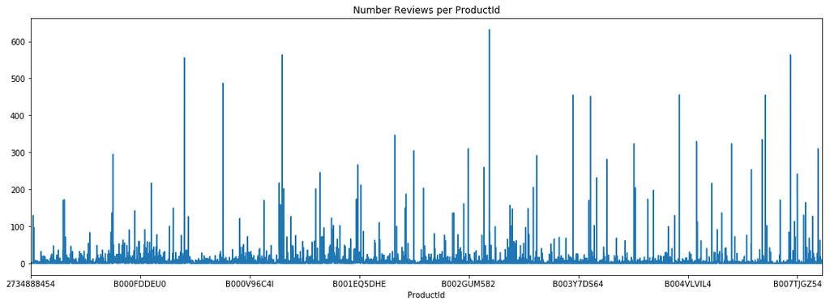

```python
#pivot table
products_list = pd.pivot_table(data_tu,index=["ProductId"],values=["Score"],aggfunc=[np.mean,len])

#multindex and plot
(products_list['len']['Score']).plot(figsize=(18, 6))
plt.title('Number Reviews per ProductId')
plt.show()
```

Give me the Top 10 ProductId's with the most comments.

```python
(products_list.sort_values([('len', 'Score')], ascending=False)).head(10)
```

| ProductId | mean Score | len Score |
| --- | --- | --- |
| B002QWP89S | 4.588608 | 632 |
| B0013NUGDE | 4.310284 | 564 |
| B007M83302 | 4.310284 | 564 |
| B000KV61FC | 3.411871 | 556 |
| B000PDY3P0 | 4.355236 | 487 |
| B004SRH2B6 | 3.671053 | 456 |
| B006N3IG4K | 3.934066 | 455 |
| B003VXFK44 | 3.934066 | 455 |
| B0041NYV8E | 3.139381 | 452 |
| B001LG945O | 3.504323 | 347 |

### Let's look at all the comments for a specific Product Id with low scores of 1 or 2.

- Using the 1/10th set: B002QWP89S
- **Note:** This part of the EDA dealing with NLP is outside the scope of this tutorial, so I'll run through this part at a high level. But happy to share this code with you. The goal here is to get a general sense of what people are complaining about that made them rate this product low.

```python
import nltk
from nltk.corpus import stopwords
from nltk.tokenize import RegexpTokenizer
from sklearn.feature_extraction.text import TfidfVectorizer
```

**Cat: Ask to read some of the text**

```python
selected_product = data_tu.loc[(data_tu['ProductId'] == 'B002QWP89S')]

print((selected_product.reset_index()).Text.sum())
```

```
my 12 year old sheltie has chronic brochotitis, been on meds for three years, these help with the coughing fits at night. so I like them!!!<br /> one bite and both my dogs are addicted!!! be warned!!! 7 pm both shelties are on my lap howling for the drug fix! I am a dog trainer and have never seen  …
```

```python
low_rv_score_prod_comments = data_tu.loc[(data_tu['ProductId']=='B002QWP89S') & (data_tu['Score'] <= 2)]
print(len(low_rv_score_prod_comments))
```

```
39
```

```python
low_rv_score_prod_comments[['Summary', 'Text', 'Score']][:5]
```

|  | Summary | Text | Score |
| --- | --- | --- | --- |
| 21014 | Check Contents First | Half way through the supply, I noticed that th... | 1 |
| 21019 | very dangerous product for dogs | i bought this for my dog - he loved it. howev... | 1 |
| 21124 | Dog got sick | Been buying greenies for years. Decide to try... | 2 |
| 21282 | Dog goes crazy for these | EDIT: I had been giving my dog a half of one o... | 2 |
| 21306 | Greenies Lite - Not for dogs who had the taste... | My little dog who's rather picky about his tre... | 1 |

**TF-IDF:** In dealing with text, no tutorial is complete with introducing TF-IDF which is the term-frequency inverse-document-frequency. This is essentially a weighting formula that upweights words that occur frequently within a sentence review but not all across all reviews, like common words such as 'these', 'those'.

[figure not shown]

```python
#going to vectorize one term and then phrases of two terms
vectorizer = TfidfVectorizer(ngram_range=(1,2))

#make a corpus that the vectorizer can read as a list
corpus = low_rv_score_prod_comments['Text'].tolist()
matrix = vectorizer.fit_transform(corpus)
```

```python
matrix
```

```
<39x4308 sparse matrix of type '<class 'numpy.float64'>'
	with 6578 stored elements in Compressed Sparse Row format>
```

```python
"""

Note: Since version 0.15, the tf-idf score of each feature can be retrieved via
the attribute idf_ of the TfidfVectorizer object:

"""
idf = vectorizer.idf_
```

```python
idf.shape
```

```
(4308,)
```

```python
terms = dict(zip(vectorizer.get_feature_names(), idf))
```

```python
terms
```

[output not shown]

[output cut: 946 more lines]

```
 'this may': 3.9957322735539909,
 'though he': 3.9957322735539909,
 'was having': 3.9957322735539909,
 'folks that': 3.9957322735539909,
 '30 regular': 3.9957322735539909,
 'with more': 3.9957322735539909,
 '12hrs later': 3.9957322735539909,
 'imagine': 3.9957322735539909,
 'greenies which': 3.9957322735539909,
 'is posion': 3.9957322735539909,
 'them out': 3.3025850929940459,
 'was that': 3.9957322735539909,
 'it so': 3.9957322735539909,
 'quote': 3.9957322735539909,
 ...}
```

```python
from wordcloud import WordCloud
```

```python
#run below only if you forgot to download the stopwords corpus
#nltk.download()
#alternatively, it's easier to go into your console/terminal and run:
# >python
# >nltk.download()
# a handy GUI will pop up and you can go to "modules" and look up 'stopwords'
```

```python
# Initialize the word cloud

wc = WordCloud(
    background_color="white",
    max_words=2000,
    width = 1024,
    height = 720,
    stopwords=stopwords.words("english")
)

# Generate the cloud

wc.generate_from_frequencies(terms)
wc.to_file("word_cloud.png")
```

```
<wordcloud.wordcloud.WordCloud at 0x11d363d68>
```

# SciKit-Learn

Scikit-Learn is probably the most popular Python machine learning package out there. It was the first package I worked in and has a vibrant and well documented community. You can use sklearn for unsupervised and supervised machine learning. Today we will build a supervised multi-class classification model for text classification. You've already seen how we used sklearn for TF-IDF processing of the product comments.

- Multinomial Naive Bayes
- Logistic Regression
- Support Vector Machine

[figure not shown]

```python
import sklearn
from sklearn.model_selection import train_test_split
from sklearn.pipeline import Pipeline
from sklearn.feature_extraction.text import TfidfVectorizer
from sklearn.linear_model import LogisticRegression
from sklearn.svm import LinearSVC
from sklearn.naive_bayes import MultinomialNB
from sklearn.cross_validation import cross_val_score
from sklearn.cross_validation import KFold
```

### Part 1 - Data for the Model

For all our models moving forward in the three packages, we'll keep it simple and use as our input features simply the Amazon Reviews `Text` and for our output targets the Amazon Review Score `Score`.

```python
data_for_model = data_tu[['Score', 'Text']].copy()
```

```python
data_for_model.head(3)
```

|  | Score | Text |
| --- | --- | --- |
| 0 | 5 | I have bought several of the Vitality canned d... |
| 1 | 1 | Product arrived labeled as Jumbo Salted Peanut... |
| 2 | 4 | This is a confection that has been around a fe... |

**Can anyone tell me why we'd want to make our score categorical?**

```python
#make 'Score' categorical
data_for_model['Score'] = data_for_model['Score'].astype('category')

print(data_for_model.dtypes)
```

```
Score    category
Text       object
dtype: object
```

**Partition the dataset:**

- Training Set to fit the model and run cross-validation on
- Validation Set as a "preemptive" test or hold-out set like a first-gate quality check
- Test Set to predict

```python
#First partition a training and test set
#converts to arrays
X = data_for_model['Text']
y = data_for_model['Score']
```

Vectorize all the Text just like we did with the Greenies Dog Treats. These will be our `features` and `labels` that we'll split on.

```python
from sklearn.feature_extraction.text import TfidfVectorizer

tfidf = TfidfVectorizer(sublinear_tf=True, min_df=5, norm='l2', encoding='latin-1')

features = tfidf.fit_transform(X).toarray()

labels = y

features.shape
```

```
(56845, 14152)
```

```python
#features is a sparse array for of 14152 features (terms) (in this vectorization I only included unigrams)
features
```

```
array([[ 0.,  0.,  0., ...,  0.,  0.,  0.],
       [ 0.,  0.,  0., ...,  0.,  0.,  0.],
       [ 0.,  0.,  0., ...,  0.,  0.,  0.],
       ...,
       [ 0.,  0.,  0., ...,  0.,  0.,  0.],
       [ 0.,  0.,  0., ...,  0.,  0.,  0.],
       [ 0.,  0.,  0., ...,  0.,  0.,  0.]])
```

```python
#split the dataset by 70% and 30%
X_train, X_test, y_train, y_test= train_test_split(features, labels, test_size=0.30, random_state=0)
```

**TIP:**</font> I usually always print out the shapes of my partitioned sets.

```python
print(X_train.shape)
print(X_test.shape)
print(y_train.shape)
print(y_test.shape)
```

```
(39791, 14152)
(17054, 14152)
(39791,)
(17054,)
```

### Part 2 - Prepare and Fit a Multinomial Bayes Model

A basic and effective technique for document classification using the Bayes Probability Theorem.

[figure not shown]

Calculate the Priors:

- Probability(1-Star Review) = P(1)
- Probability(2-Star Review) = P(2)
- and so on...

Calculate the Likelihood (aka Conditional Probabilities):

P('treats'|5) = [(count('treats', 5) + 1] **divided by** [(count(5-star reviews) + |V|]; where V is the set(words), or number of all unique words

Calculate Probability for a Document (or an Amazon Review, in our case)

P(5|this_review) = P(5) *P('word1'|5)* P('word2'|5) *P('word3'|5) ...* P('word_k'|5)  
P(5|this_review) = 0.4 *0.05256* 0.00345 *0.012* 0.004 = 0.0000000348

Repeat for P(4|this review)... to P(1|this_review)

The probability with the greatest value is the catgory (the star-rating) of the Amazon Review.

**2 - Fit the MultinomialNB() Model**

```python
mn_clf = MultinomialNB().fit(X_train, y_train)
```

**3- Cross Validate on the Training Set**

**What is cross validation?**

Cross validation is a strategy to prevent overfitting.

```python
from sklearn.cross_validation import cross_val_score
from scipy.stats import sem


cv = cross_val_score(mn_clf, X_train, y=y_train, scoring='accuracy', cv=5)
print(cv)
print("Mean score:{0:.3f}(+/-{1:.3f})".format(np.mean(cv),sem(cv)))
```

```
[ 0.63245823  0.6307325   0.63470721  0.63277617  0.63084465]
Mean score:0.632(+/-0.001)
```

When running this model for neg_mse: [-0.15134227 -0.15240006 -0.14842328 -0.15081189 -0.15257609] Mean score:-0.151(+/-0.001)

**4 - Evaluation Metrics**

- Classification Report
- Confusion Matrix
- Learning Curve

```python
from sklearn.metrics import classification_report
from sklearn.metrics import confusion_matrix
```

**Predict** On the X_test set, that if you remember, we vectorized early on.

```python
y_pred = mn_clf.predict(X_test)
```

We can see here that we want all the numbers to line up totally on the diagonal. For example, the model predicted that 186 of the 1671 1-Star rating reviews were 1-star (prediction). This is right! But unfortunately, it predicted that 11 of them were a 4-star, and that's wrong. Worse, it predicted that a huge number, 1473 of the reviews that are actually 1-star are a 5-star.

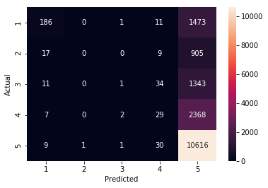

```python
conf_mat = sklearn.metrics.confusion_matrix(y_test, y_pred)
sns.heatmap(conf_mat, annot=True, fmt='d', xticklabels=['1', '2', '3', '4', '5'], yticklabels=['1', '2', '3', '4', '5'])
plt.ylabel('Actual')
plt.xlabel('Predicted')
plt.show()
```

It confuses many of the reviews as being a 5-star, which shows in our f1-score below. You can see our f1-scores for 2-star, 3-star, and 4-star are especially bad.

[figure not shown]

```python
print(sklearn.metrics.classification_report(y_test, y_pred))
```

```
             precision    recall  f1-score   support

          1       0.81      0.11      0.20      1671
          2       0.00      0.00      0.00       931
          3       0.20      0.00      0.00      1389
          4       0.26      0.01      0.02      2406
          5       0.64      1.00      0.78     10657

avg / total       0.53      0.64      0.51     17054
```

```python
sklearn.metrics.accuracy_score(y_test, y_pred)
```

```
0.63515890700129007
```

### Part 3 - Automate with a Pipeline

**Let's fit a few models using a pipeline.**

- In the pipeline, we'll ask the it to first vectorize the review comments.
- Then the pipeline will instantiate a classifier.

[figure not shown]

We will use our original non-vectorized dataset X and y to run through the pipeline for three different classifiers.

```python
X_train, X_test, y_train, y_test= train_test_split(X, y, test_size=0.30, random_state=0)
```

**Something you might want to try yourself - Challenge Question:** How does the cross validation scores change if we add a new parameter of `ngram_range=(1, 2)`?

```python
clf_1 = Pipeline([
    ('vect', TfidfVectorizer(decode_error='ignore', strip_accents='unicode', stop_words='english')),
    ('clf', MultinomialNB()),
])


clf_2 = Pipeline([
    ('vect', TfidfVectorizer(decode_error='ignore', strip_accents='unicode', stop_words='english')),
    ('clf', LogisticRegression()),
])


clf_3 = Pipeline([
    ('vect', TfidfVectorizer(decode_error='ignore', strip_accents='unicode', stop_words='english')),
    ('clf', LinearSVC()),
])
```

```python
#Function to perform and evaluate a cross validation on the training set
from sklearn.model_selection import cross_validate

def evaluate_cross_validation(clf, X, y, K):
    cv = KFold(len(y), n_folds = K, shuffle=True)
    scores = cross_val_score(clf, X, y, cv=cv, scoring='accuracy')
    print(clf.named_steps['clf'], scores)
    print("Mean score:{0:.3f}(+/-{1:.3f})".format(np.mean(scores),sem(scores)))
```

```python
%%time

"""
On a CPU, this takes approximately 9min 45s on a MacBook Pro:

Processor: 2.8 GHz Intel Core i7
Memory: 16 GB 2133 MHz LPDDR3

"""

#Evaluate each model using the K-fold cross-validation with 5 folds
clfs = [clf_1, clf_2, clf_3]

for clf in clfs:
    evaluate_cross_validation(clf, X_train, y_train, 5)
```

```
MultinomialNB(alpha=1.0, class_prior=None, fit_prior=True) [ 0.62746576  0.6319427   0.63495853  0.61221412  0.6235235 ]
Mean score:0.626(+/-0.004)
LogisticRegression(C=1.0, class_weight=None, dual=False, fit_intercept=True,
          intercept_scaling=1, max_iter=100, multi_class='ovr', n_jobs=1,
          penalty='l2', random_state=None, solver='liblinear', tol=0.0001,
          verbose=0, warm_start=False) [ 0.69807765  0.6946469   0.69552651  0.69502388  0.69904499]
Mean score:0.696(+/-0.001)
LinearSVC(C=1.0, class_weight=None, dual=True, fit_intercept=True,
     intercept_scaling=1, loss='squared_hinge', max_iter=1000,
     multi_class='ovr', penalty='l2', random_state=None, tol=0.0001,
     verbose=0) [ 0.70863174  0.70495099  0.70382006  0.70080422  0.69426992]
Mean score:0.702(+/-0.002)
CPU times: user 1min 14s, sys: 750 ms, total: 1min 15s
Wall time: 52.8 s
```

neg_mse: MultinomialNB(alpha=1.0, class_prior=None, fit_prior=True) [-0.15573106 -0.15842308 -0.15960476 -0.15691428 -0.16354612] Mean score:-0.159(+/-0.001) LogisticRegression(C=1.0, class_weight=None, dual=False, fit_intercept=True, intercept_scaling=1, max_iter=100, multi_class='ovr', n_jobs=1, penalty='l2', random_state=None, solver='liblinear', tol=0.0001, verbose=0, warm_start=False) [-0.09203315 -0.0938875 -0.09311852 -0.09124335 -0.0869679 ] Mean score:-0.091(+/-0.001) LinearSVC(C=1.0, class_weight=None, dual=True, fit_intercept=True, intercept_scaling=1, loss='squared_hinge', max_iter=1000, multi_class='ovr', penalty='l2', random_state=None, tol=0.0001, verbose=0) [-0.07691401 -0.07498595 -0.07639416 -0.0819678 -0.08198511] Mean score:-0.078(+/-0.001)

**Model Selection**

```python
#original

def train_and_evaluate(clf, X_train, X_test, y_train, y_test):

    clf.fit(X_train, y_train)

    print("Accuracy on training set:")
    print(clf.score(X_train, y_train))
    print("Accuracy on testing set:")
    print(clf.score(X_test, y_test))

    y_pred = clf.predict(X_test)

    print("Classification Report:")
    print(sklearn.metrics.classification_report(y_test, y_pred, target_names = ['1', '2', '3', '4', '5']))
    print("Confusion Matrix:")
    print(sklearn.metrics.confusion_matrix(y_test, y_pred))
```

We'll see that using a SVM increased our F1-Score a bit more, enabling the model to better predict the correct classes. A good tutorial that discusses the linearSVC model, which is a linear kernel function of the Support Vector Machine is by Alice Zhou, here's her video: https://www.youtube.com/watch?v=N1vOgolbjSc. As well as one by Brandon Ruhrer: https://www.youtube.com/watch?v=-Z4aojJ-pdg

One of the key elements of understanding SVM's is what's called the "kernel trick". This is essentially a way to best slice your data using a "hyperplane". There are different types of kernels, this one is a linear kernel. There are radial basis functions (rbf), polynomial, and sigmoid kernels.

[figure not shown]

The trick of bending this piece of paper in the right way to get that hyperplane that separates let's say, per Brandon, good to eat plums from bad to eat plums, is calculated through a formula called the 'kernel'. One drawback is the calculation time for large datasets to compute the kernel.

[figure not shown]

**Something you might want to try yourself - Challenge Question:** How would the `clf_3` change if we changed its penalty parameter of 'C' to a lower value? My guess is that when C decreases, it makes a "soft margin" separating our 5 different classes. This may mean a less accurate score. You try!

```python
%%time

#I chose to use model clf_3

train_and_evaluate(clf_3, X_train, X_test, y_train, y_test)
```

```
Accuracy on training set:
0.88763790807
Accuracy on testing set:
0.704057699074
Classification Report:
             precision    recall  f1-score   support

          1       0.63      0.60      0.62      1671
          2       0.36      0.19      0.25       931
          3       0.42      0.25      0.31      1389
          4       0.40      0.25      0.31      2406
          5       0.78      0.93      0.85     10657

avg / total       0.66      0.70      0.67     17054

Confusion Matrix:
[[1002  117  101   92  359]
 [ 225  180  148   96  282]
 [ 136  104  345  254  550]
 [  65   47  121  609 1564]
 [ 159   47  108  472 9871]]
CPU times: user 10.8 s, sys: 127 ms, total: 10.9 s
Wall time: 10.9 s
```

### Part 4 - Model Evaluation</h3>

You can see that using SVMs, reduce our mis-classification errors.

```python
def confusion_matrix_heatmap(clf, X_train, X_test, y_train, y_test):
    clf.fit(X_train, y_train)
    y_pred = clf.predict(X_test)
    conf_mat = sklearn.metrics.confusion_matrix(y_test, y_pred)
    sns.heatmap(conf_mat, annot=True, fmt='d', xticklabels=['1', '2', '3', '4', '5'], yticklabels=['1', '2', '3', '4', '5'])
    plt.ylabel('Actual')
    plt.xlabel('Predicted')
    plt.show()
```

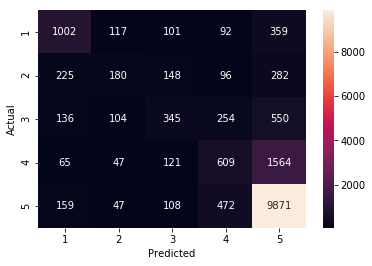

```python
confusion_matrix_heatmap(clf_3, X_train, X_test, y_train, y_test)
```

Now let's run a learning curve. Don't worry about making sense of the code in the plot. Let's just copy and paste it in to run the learning curve.

```python
from sklearn.model_selection import learning_curve

def plot_learning_curve(estimator, title, X, y, ylim=None, cv=None,
                        n_jobs=1, train_sizes=np.linspace(.1, 1.0, 5)):
    plt.figure()
    plt.title(title)
    if ylim is not None:
        plt.ylim(*ylim)
    plt.xlabel("Training examples")
    plt.ylabel("Score")
    train_sizes, train_scores, test_scores = learning_curve(
        estimator, X, y, cv=cv, n_jobs=n_jobs, train_sizes=train_sizes)
    train_scores_mean = np.mean(train_scores, axis=1)
    train_scores_std = np.std(train_scores, axis=1)
    test_scores_mean = np.mean(test_scores, axis=1)
    test_scores_std = np.std(test_scores, axis=1)
    plt.grid()

    plt.fill_between(train_sizes, train_scores_mean - train_scores_std,
                     train_scores_mean + train_scores_std, alpha=0.1,
                     color="r")
    plt.fill_between(train_sizes, test_scores_mean - test_scores_std,
                     test_scores_mean + test_scores_std, alpha=0.1, color="g")
    plt.plot(train_sizes, train_scores_mean, 'o-', color="r",
             label="Training score")
    plt.plot(train_sizes, test_scores_mean, 'o-', color="g",
             label="Cross-validation score")

    plt.legend(loc="best")
    return plt
```

By adding more data (more than our 1/10th of the dataset!), we could probably increase our accuracy. You want to see these lines converge, so that the training is not overfit and the validation accuracy is improving.

```
<module 'matplotlib.pyplot' from '/Users/catherineordun/anaconda/envs/py35/lib/python3.5/site-packages/matplotlib/pyplot.py'>
```

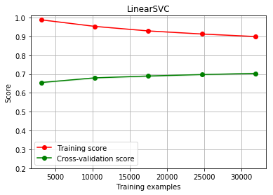

```python
plot_learning_curve(clf_3, 'LinearSVC', X_train, y_train, ylim=(0.2, 1.01), cv=5, n_jobs=4)
```

### Part 5 - Let's Predict!</h3>

[figure not shown]

```python
#2-star
myreview = ["I didn't love this. It seemed to have so much 'something' in it that made it super-soft and super-spreadable that the flavor was a little funky and chemical-like. On the plus side, it didn't tear the bread."]
```

```python
def predict_svm(review, model):
    #myreview_vectorized = tfidf.fit_transform(review)
    yprobs = model.predict(review)
    return yprobs
```

```python
predict_svm(myreview, clf_3)
```

```
array([3])
```

[figure not shown]

```python
#1-star
myreview=["This is most disgustingly sweet thing I've ever tasted. I don't know what I was thinking when I ordered this"]
```

```python
predict_svm(myreview, clf_3)
```

```
array([1])
```

[figure not shown]

```python
myreview=["Umm. Bought this on a whim and it is crazy good. Tastes like chocolate and a lot like cheesecake. Not sure how to eat it yet but a spoon works!"]
```

```python
predict_svm(myreview, clf_3)
```

```
array([4])
```

[figure not shown]

```python
myreview=["chocolate cheesecake hazelnut. yum yum yum. need to buy more or they need to make a bigger container."]
```

```python
predict_svm(myreview, clf_3)
```

```
array([5])
```

[figure not shown]

```python
myreview=["sweet, but not too sweet. Can definitely taste the cheesecake, will buy again"]
```

```python
predict_svm(myreview, clf_3)
```

```
array([5])
```

```python
#enter your own review for Amazon related foods
#myreview = ["yourtext"]
#print(predict_svm(myreview, clf_3_))
```

## Short Break - 5 min</h2></font>

# H2O

With H2O we'll build a stacked ensemble:

H2O makes this easy. We will make to classification models using a Logistic Regression and Gradient Boosted Model. These models are fit on the training data. The outputs of those predictions are then fed into what is called a "Meta Learner". That Meta Learner will be a Gradient Boosted Model. It learns on those predictions The ensemble model then learns on the predictions from the training sets, and outputs the predictions on the test. The two base learners we will build in H2O are:

- Logistic Regression Model
- Gradient Boosted Model

[figure not shown]

H2O will generate a "Level 1" dataset which are the predicted classes (star reviews) for each of our reviews in the training set for each of the models: n x m = len(training) x 2

At the same time, it will predict for the x_test using each of these base learners. These will generate the test predictions we'll call "meta_test".

The Meta Learner will train on the Level 1 dataset.

meta_learner.fit(level1, y_train)  
meta_learner.predict(meta_test) #will generate all the y_test labels

We'll use the `H2OStackedEnsembleEstimator` metalearner setting at the default 'AUTO' and then make it a Gradient Boosted Model in itself to compare the mean squared error for each.

[figure not shown]

There are a few things we need to do here in this part of the tutorial:

- Part 1 - Prepare the data using an H2OFrame
- Part 2 - Tokenize the Reviews
- Part 3 - Train a Word2Vec model on the entire Amazon Reviews and transform the data_tu Text
- Part 4 - Partition the data into a 60/20/20 split
- Part 5 - Develop Base Learners and stack into an Ensemble
- Part 6 - Make Predictions!

```python
import h2o
from h2o.estimators.gbm import H2OGradientBoostingEstimator
from h2o.estimators.stackedensemble import H2OStackedEnsembleEstimator
from h2o.estimators.naive_bayes import H2ONaiveBayesEstimator
from h2o.estimators.glm import H2OGeneralizedLinearEstimator
from h2o.grid.grid_search import H2OGridSearch
from __future__ import print_function
h2o.init()
```

[output not shown]

| H2O cluster uptime: | 02 secs |
| --- | --- |
| H2O cluster timezone: | America/New_York |
| H2O data parsing timezone: | UTC |
| H2O cluster version: | 3.18.0.4 |
| H2O cluster version age: | 7 days, 12 hours and 56 minutes |
| H2O cluster name: | H2O_from_python_catherineordun_8561xp |
| H2O cluster total nodes: | 1 |
| H2O cluster free memory: | 3.556 Gb |
| H2O cluster total cores: | 8 |
| H2O cluster allowed cores: | 8 |
| H2O cluster status: | accepting new members, healthy |
| H2O connection url: | http://127.0.0.1:54321 |
| H2O connection proxy: | None |
| H2O internal security: | False |
| H2O API Extensions: | XGBoost, Algos, AutoML, Core V3, Core V4 |
| Python version: | 3.5.4 final |

### Part 1 - Prepping the Data</h3> Data must be in an H2OFrame H2OFrame is similar to pandas’ DataFrame, or R’s data.frame. One of the critical distinction is that the data is generally not held in memory, instead it is located on a (possibly remote) H2O cluster, and thus H2OFrame represents a mere handle to that data.

```python
train = h2o.H2OFrame(data_tu)
train.head(2)
```

```
Parse progress: |█████████████████████████████████████████████████████████| 100%
```

| Id | ProductId | UserId | ProfileName | HelpfulnessNumerator | HelpfulnessDenominator | Score | Time | Summary | Text | datetime |
| --- | --- | --- | --- | --- | --- | --- | --- | --- | --- | --- |
| 1 | B001E4KFG0 | A3SGXH7AUHU8GW | delmartian | 1 | 1 | 5 | 1.30386e+09 | Good Quality Dog Food | I have bought several of the Vitality canned dog food products and have found them all to be of good quality. The product looks more like a stew than a processed meat and it smells better. My Labrador… | 2011-04-26 00:00:00 |
| 2 | B00813GRG4 | A1D87F6ZCVE5NK | dll pa | 0 | 0 | 1 | 1.34698e+09 | Not as Advertised | Product arrived labeled as Jumbo Salted Peanuts...the peanuts were actually small sized unsalted. Not sure if this was an error or if the vendor intended to represent the product as ""Jumbo" | 2012-09-06 00:00:00 |

```python
train.describe()
```

```
Rows:56845
Cols:11
```

|  | Id | ProductId | UserId | ProfileName | HelpfulnessNumerator | HelpfulnessDenominator | Score | Time | Summary | Text | datetime |
| --- | --- | --- | --- | --- | --- | --- | --- | --- | --- | --- | --- |
| type | int | enum | string | enum | int | int | int | int | enum | string | time |
| mins | 1.0 |  | NaN |  | 0.0 | 0.0 | 1.0 | 961718400.0 |  | NaN | 961632000000.0 |
| mean | 28423.0 |  | NaN |  | 1.615146450875185 | 2.084264227284717 | 4.145184273023132 | 1295378629.803853 |  | NaN | 1295292229803.8535 |
| maxs | 56845.0 |  | NaN |  | 398.0 | 401.0 | 5.0 | 1351209600.0 |  | NaN | 1351123200000.0 |
| sigma | 16409.882362974655 |  | NaN |  | 5.4468852423750835 | 6.105144407269138 | 1.3314108619987988 | 47217068.042775914 |  | NaN | 47217068042.775986 |
| zeros | 0 |  | 0 |  | 30536 | 27220 | 0 | 0 |  | 0 | 0 |
| missing | 0 | 0 | 0 | 0 | 0 | 0 | 0 | 0 | 0 | 0 | 0 |
| 0 | 1.0 | B001E4KFG0 | A3SGXH7AUHU8GW | delmartian | 1.0 | 1.0 | 5.0 | 1303862400.0 | Good Quality Dog Food | I have bought several of the Vitality canned dog food products and have found them all to be of good quality. The product looks more like a stew than a processed meat and it smells better. My Labrador… | 2011-04-26 00:00:00 |
| 1 | 2.0 | B00813GRG4 | A1D87F6ZCVE5NK | dll pa | 0.0 | 0.0 | 1.0 | 1346976000.0 | Not as Advertised | Product arrived labeled as Jumbo Salted Peanuts...the peanuts were actually small sized unsalted. Not sure if this was an error or if the vendor intended to represent the product as ""Jumbo" | 2012-09-06 00:00:00 |
| 2 | 3.0 | B000LQOCH0 | ABXLMWJIXXAIN | Natalia Corres ""Natalia Corres | 1.0 | 1.0 | 4.0 | 1219017600.0 | ""Delight"" says it a | This is a confection that has been around a few centuries. It is a light, pillowy citrus gelatin with nuts - in this case Filberts. And it is cut into tiny squares and then liberally coated with powde… | 2008-08-17 00:00:00 |
| 3 | 4.0 | B000UA0QIQ | A395BORC6FGVXV | Karl | 3.0 | 3.0 | 2.0 | 1307923200.0 | Cough Medicine | If you are looking for the secret ingredient in Robitussin I believe I have found it. I got this in addition to the Root Beer Extract I ordered (which was good) and made some cherry soda. The flavor i… | 2011-06-12 00:00:00 |
| 4 | 5.0 | B006K2ZZ7K | A1UQRSCLF8GW1T | Michael D. Bigham ""M. Wassir | 0.0 | 0.0 | 5.0 | 1350777600.0 | Great taffy | Great taffy at a great price. There was a wide assortment of yummy taffy. Delivery was very quick. If your a taffy lover, this is a deal. | 2012-10-20 00:00:00 |
| 5 | 6.0 | B006K2ZZ7K | ADT0SRK1MGOEU | Twoapennything | 0.0 | 0.0 | 4.0 | 1342051200.0 | Nice Taffy | I got a wild hair for taffy and ordered this five pound bag. The taffy was all very enjoyable with many flavors: watermelon, root beer, melon, peppermint, grape, etc. My only complaint is there was a … | 2012-07-11 00:00:00 |
| 6 | 7.0 | B006K2ZZ7K | A1SP2KVKFXXRU1 | David C. Sullivan | 0.0 | 0.0 | 5.0 | 1340150400.0 | Great! Just as good as the expensive brands! | This saltwater taffy had great flavors and was very soft and chewy. Each candy was individually wrapped well. None of the candies were stuck together, which did happen in the expensive version, Fralin… | 2012-06-19 00:00:00 |
| 7 | 8.0 | B006K2ZZ7K | A3JRGQVEQN31IQ | Pamela G. Williams | 0.0 | 0.0 | 5.0 | 1336003200.0 | Wonderful, tasty taffy | This taffy is so good. It is very soft and chewy. The flavors are amazing. I would definitely recommend you buying it. Very satisfying!! | 2012-05-02 00:00:00 |
| 8 | 9.0 | B000E7L2R4 | A1MZYO9TZK0BBI | R. James | 1.0 | 1.0 | 5.0 | 1322006400.0 | Yay Barley | Right now I'm mostly just sprouting this so my cats can eat the grass. They love it. I rotate it around with Wheatgrass and Rye too | 2011-11-22 00:00:00 |
| 9 | 10.0 | B00171APVA | A21BT40VZCCYT4 | Carol A. Reed | 0.0 | 0.0 | 5.0 | 1351209600.0 | Healthy Dog Food | This is a very healthy dog food. Good for their digestion. Also good for small puppies. My dog eats her required amount at every feeding. | 2012-10-25 00:00:00 |

Need to convert our target, `Score` to a categorical because by default H2O reads in `Score` as an int. For H2O integers are used so they can be mapped to categorical (using .asfactor()). “enum” - force the column to be parsed as a categorical column.

- If we don't do this, the models will try to predict as a regression model, not classification.

```python
train['Score'] = train['Score'].asfactor()
```

```python
train = train[['Text', 'Score']]
```

```python
train.describe()
```

```
Rows:56845
Cols:2
```

|  | Text | Score |
| --- | --- | --- |
| type | string | enum |
| mins | NaN |  |
| mean | NaN |  |
| maxs | NaN |  |
| sigma | NaN |  |
| zeros | 0 |  |
| missing | 0 | 0 |
| 0 | I have bought several of the Vitality canned dog food products and have found them all to be of good quality. The product looks more like a stew than a processed meat and it smells better. My Labrador… | 5 |
| 1 | Product arrived labeled as Jumbo Salted Peanuts...the peanuts were actually small sized unsalted. Not sure if this was an error or if the vendor intended to represent the product as ""Jumbo" | 1 |
| 2 | This is a confection that has been around a few centuries. It is a light, pillowy citrus gelatin with nuts - in this case Filberts. And it is cut into tiny squares and then liberally coated with powde… | 4 |
| 3 | If you are looking for the secret ingredient in Robitussin I believe I have found it. I got this in addition to the Root Beer Extract I ordered (which was good) and made some cherry soda. The flavor i… | 2 |
| 4 | Great taffy at a great price. There was a wide assortment of yummy taffy. Delivery was very quick. If your a taffy lover, this is a deal. | 5 |
| 5 | I got a wild hair for taffy and ordered this five pound bag. The taffy was all very enjoyable with many flavors: watermelon, root beer, melon, peppermint, grape, etc. My only complaint is there was a … | 4 |
| 6 | This saltwater taffy had great flavors and was very soft and chewy. Each candy was individually wrapped well. None of the candies were stuck together, which did happen in the expensive version, Fralin… | 5 |
| 7 | This taffy is so good. It is very soft and chewy. The flavors are amazing. I would definitely recommend you buying it. Very satisfying!! | 5 |
| 8 | Right now I'm mostly just sprouting this so my cats can eat the grass. They love it. I rotate it around with Wheatgrass and Rye too | 5 |
| 9 | This is a very healthy dog food. Good for their digestion. Also good for small puppies. My dog eats her required amount at every feeding. | 5 |

### Part 2 - Tokenize </h3> Word2Vec requires words, instead of sentences. So, we need to tokenize the review comments.

```python
#I did not filter out stopwords
words = (train["Text"].tokenize("\\W+")).tolower()
```

```python
words.shape
```

```
(4743259, 1)
```

```python
words
```

### Part 3 - Train a Word2Vec Model</h3>

[figure not shown]

It's hard to do a tutorial involving machine learning and text and **not** talk about word2vec. Each word is assigned a vector - or an array of numbers.

> { 'yellow': array([0.1,0.5,...,0.7]), 'four': array([0.2,1.2,...,0.9]), ... }

Word2Vec will then train the words against other words and will learn "vector representations" of the words called "embeddings", which I usually think about as groupings. Similar words will be placed close to each other in the vector space using l2 or cosine similarity.

> Per Chollet, "Ideally, in a good embeddings space, the "path" (a vector) to go from "kitchen" and "dinner" would capture precisely the semantic relationship between these two concepts." The below Word2Vec Model was trained on the **entire** corpus of Amazon Review Comments.

[figure not shown]

```python
#Word2Vec model - DO NOT RUN THIS AGAIN

#Takes 30 minutes to train
from h2o.estimators.word2vec import H2OWord2vecEstimator

w2v_model = H2OWord2vecEstimator(sent_sample_rate = 0.0, epochs = 10)
w2v_model.train(training_frame=words)
```

For H2O and Keras that we'll show in a few minutes, it's very important to save your models. For this Word2Vec model, which saves a series of weights, it took 30 minutes to train this on my CPU. As a result, make sure you save it. Then you can reload it. In this case, in my tutorial I'm reloading it as `w2v_model_saved`.

```python
#Save this model
#w2v_path = h2o.save_model(model=w2v_model, path="/Users/catherineordun/Documents/Data/", force=True)
```

```python
#Load the model
#this one only works in the older version of h2o
#w2v_model_saved = h2o.load_model("Word2Vec_model_python_1520181217021_1")
#load the new version since h2o got upgraded 3.18.0.4
w2v_model_saved = h2o.load_model("Word2Vec_model_python_1520817325605_1")
```

```python
#look at the w2v_model
w2v_model_saved
```

```
Model Details
=============
H2OWord2vecEstimator :  Word2Vec
Model Key:  Word2Vec_model_python_1520817325605_1
No model summary for this model
```

**Similarity:** To make sure it's been trained correctly, you can examine similar words. In this case, since we already examined comments about the "Greenies" dog treats, let's see what similar words are associated with it.

```python
#find similar words to greenies, return 5 synonyms
w2v_model_saved.find_synonyms("greenies", count = 5)
```

```
OrderedDict([('chews', 0.8226943612098694),
             ('treats', 0.7436110377311707),
             ('cet', 0.7425161004066467),
             ('chewies', 0.7313610315322876),
             ('dental', 0.6978490352630615)])
```

```python
w2v_model_saved.find_synonyms("puppy", count = 5)
```

```
OrderedDict([('beagle', 0.8231599926948547),
             ('yorkie', 0.8218944072723389),
             ('pug', 0.817716658115387),
             ('puggle', 0.8069885969161987),
             ('westie', 0.8062203526496887)])
```

```python
w2v_model_saved.find_synonyms("chocolate", count = 5)
```

```
OrderedDict([('cocoa', 0.7393110990524292),
             ('dark', 0.7252026796340942),
             ('choc', 0.7176589369773865),
             ('choco', 0.7154401540756226),
             ('bittersweet', 0.6949163675308228)])
```

```python
#change the number of synonyms for another word
#w2v_model_saved.find_synonyms("yourword", count = your_int)
```

**Vectors for each Review**

```python
#Calculate a vector for each of our 56,845 Amazon Reviews
review_vecs = w2v_model_saved.transform(words, aggregate_method = "AVERAGE")
```

```python
#returns: a frame representing learned word embeddings
review_vecs
```

| C1 | C2 | C3 | C4 | C5 | C6 | C7 | C8 | C9 | C10 | C11 | C12 | C13 | C14 | C15 | C16 | C17 | C18 | C19 | C20 | C21 | C22 | C23 | C24 | C25 | C26 | C27 | C28 | C29 | C30 | … |
| --- | --- | --- | --- | --- | --- | --- | --- | --- | --- | --- | --- | --- | --- | --- | --- | --- | --- | --- | --- | --- | --- | --- | --- | --- | --- | --- | --- | --- | --- | --- |
| 0.11287 | 0.0339633 | -0.0879006 | -0.0600188 | 0.0525756 | -0.143454 | 0.0696428 | -0.0725585 | -0.0353889 | 0.183916 | -0.133779 | -0.0319463 | 0.110811 | 0.00843086 | 0.00537743 | 0.13247 | -0.0278372 | -0.00981222 | -0.0948934 | -0.194546 | 0.123283 | -0.0217034 | -0.169324 | -0.198177 | 0.0989993 | -0.0610325 | -0.21759 | 0.0604038 | -0.0365773 | 0.0707142 | … |
| 0.0963334 | 0.103357 | -0.0682851 | -0.0588865 | 0.0919635 | -0.222242 | -0.0778329 | -0.0360359 | 0.145066 | 0.180324 | -0.175716 | -0.071043 | 0.0811815 | -0.0655275 | -0.0534019 | 0.0484884 | -0.146389 | 0.0178741 | -0.0237985 | -0.250993 | -0.0193418 | -0.0127054 | -0.0218012 | -0.24426 | 0.168083 | 0.0556345 | -0.290465 | 0.091929 | 0.0385481 | 0.106132 | … |
| 0.0574179 | 0.0522261 | -0.137269 | -0.141691 | -0.00991225 | -0.208629 | 0.00468167 | -0.0839169 | -0.081665 | 0.167663 | -0.131708 | -0.0574391 | 0.10915 | 0.0534703 | -0.0862437 | 0.0797423 | -0.00567731 | -0.0868583 | -0.0410473 | -0.198009 | -0.00676767 | 0.0190084 | -0.13414 | -0.167761 | 0.0872735 | -0.0834161 | -0.232609 | 0.0387656 | 0.0023074 | 0.137339 | … |
| 0.116842 | 0.102112 | -0.131886 | -0.0840896 | -0.00582807 | -0.252236 | 0.0508261 | -0.0619644 | -0.0398772 | 0.163419 | -0.0905405 | -0.0572931 | 0.0658307 | 0.0509994 | -0.0519038 | 0.0142148 | -0.136428 | -0.117865 | -0.0717383 | -0.238447 | 0.00278655 | -0.0297105 | -0.0987927 | -0.123713 | 0.103957 | 0.00871476 | -0.20339 | -0.0324505 | -0.107131 | 0.0971404 | … |
| 0.0791116 | 0.153853 | -0.209904 | -0.174645 | 0.0213742 | -0.159472 | -0.0637018 | -0.151887 | 0.00855035 | 0.187906 | -0.14084 | -0.0945815 | 0.072865 | -0.0469307 | -0.143299 | 0.0159409 | -0.109499 | -0.0233132 | -0.0230993 | -0.19327 | -0.0936468 | 0.0107373 | -0.0718995 | -0.246679 | 0.0975979 | -0.0420753 | -0.152279 | -0.0806931 | -0.0440023 | 0.185398 | … |
| 0.0497454 | 0.125603 | -0.0832521 | -0.0806048 | 0.0244931 | -0.176532 | -0.0334962 | -0.0377197 | -0.0895978 | 0.118804 | -0.0564011 | -0.0505853 | 0.0736519 | 0.0387012 | -0.0509566 | -0.00719834 | -0.0924332 | -0.0846922 | -0.0585935 | -0.219096 | 0.0238911 | 0.0507377 | -0.110823 | -0.191993 | 0.102592 | -0.0581955 | -0.224096 | -0.0372037 | -0.0188141 | 0.0844032 | … |
| 0.0318013 | 0.091518 | -0.0907559 | -0.186381 | 0.0532051 | -0.230707 | -0.0205048 | -0.0488273 | -0.0917446 | 0.137574 | -0.0882097 | -0.0449613 | 0.1198 | 0.00549219 | -0.0971941 | 0.0493753 | -0.0646762 | -0.0574882 | -0.0584734 | -0.189017 | -0.0129778 | -0.0405722 | -0.0140041 | -0.247908 | 0.163482 | -0.0264439 | -0.206168 | 0.0105792 | 0.04086 | 0.0859354 | … |
| 0.113501 | 0.115101 | -0.0851128 | -0.198364 | -0.0139688 | -0.115213 | -0.0822208 | -0.139436 | -0.0895954 | 0.173849 | -0.0986427 | -0.0914696 | 0.0961402 | 0.124756 | -0.0803599 | 0.168509 | -0.00503846 | 0.00338616 | -0.0970824 | -0.273018 | -0.0167649 | -0.057266 | -0.0656548 | -0.163448 | 0.0786647 | -0.0579015 | -0.284835 | -0.117537 | -0.115866 | 0.0829521 | … |
| 0.094573 | 0.150041 | -0.057794 | -0.0579225 | -0.0595247 | -0.193601 | 0.000465088 | -0.0279055 | -0.0186335 | 0.126326 | -0.0778039 | -0.071392 | 0.0778363 | 0.0646641 | -0.106572 | 0.0454134 | -0.0306183 | -0.0942703 | -0.187773 | -0.14144 | 0.19875 | -0.0881401 | -0.266027 | -0.237207 | 0.139226 | 0.0122016 | -0.21324 | 0.0165788 | -0.0363398 | 0.161704 | … |
| 0.120459 | 0.0738875 | 0.026443 | -0.150135 | -0.00600546 | -0.0902759 | 0.0522743 | -0.0910993 | 0.00428813 | 0.262409 | -0.301282 | -0.0134695 | 0.00601743 | -0.00125199 | -0.125965 | 0.0514454 | 0.0144128 | 0.0609418 | -0.0532717 | -0.107025 | 0.0931666 | 0.00789962 | -0.26379 | -0.273761 | 0.122762 | 0.0166619 | -0.246934 | 0.135095 | -0.0825592 | 0.121094 | … |

```python
review_vecs.shape
```

```
(56845, 100)
```

### Part 4 - Partitioning the Data</h3>

```python
#Partitioning into Train/Test Split
#Keeping only those review_vecs that have no 'NaN's

valid_reviews = ~ review_vecs["C1"].isna()


#for each of the valid_reviews, remember the ones that do not have 'NaN's, add the associated vectors
# use H2O's 'cbind' function
#this is now 'data'
data = train[valid_reviews,:].cbind(review_vecs[valid_reviews,:])

#now split this data by an 80%, 20% train/test split using H2O's 'split_frame' function
#data_split = data.split_frame(ratios=[0.8])
```

```python
#split the data into three pieces: 60% for training, 20% for validation, 20% for final testing
train, valid, test = data.split_frame(
    ratios=[0.6,0.2],
    seed=1234
)
```

### Part 5 - Build two baseline models</h3> Log Reg on 3 folds Cross Validation Gradient Boosted Machine on 3 folds Cross Validation NOTE: fold assignment and nfolds must be the same for both estimators

```python
#Logistic Regression
cv_log = H2OGeneralizedLinearEstimator(family='multinomial',
                                       solver='L_BFGS',
                                       fold_assignment="Modulo",
                                       nfolds = 3,
                                      keep_cross_validation_predictions=True)

cv_log.train(x = review_vecs.names,
             y = "Score",
             training_frame=train)
```

```
glm Model Build progress: |███████████████████████████████████████████████| 100%
```

```python
#cv_gbm = H2OGradientBoostingEstimator(nfolds = 3)

cv_gbm = H2OGradientBoostingEstimator(nfolds=3,
                                      fold_assignment="Modulo",
                                      keep_cross_validation_predictions=True)

cv_gbm.train(x = review_vecs.names,
             y = "Score",
             training_frame=train)
```

```
gbm Model Build progress: |███████████████████████████████████████████████| 100%
```

**Variable Importance** Let's see which word embedding is the most predictive specifically for one of our base models.

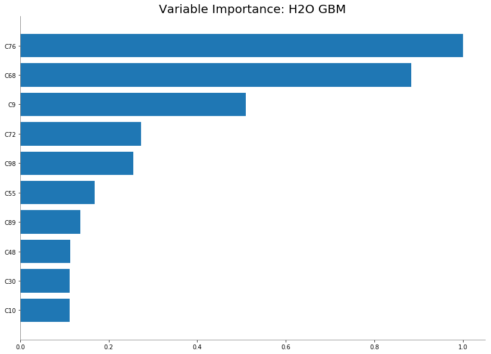

```python
cv_gbm.varimp_plot()
```

Below code sometimes times out, heap usage error on H2O (run optionally).

```python
#since the NLP part of H2O is a little out of scope of this tutorial
#I used some code courtesy of https://www.youtube.com/watch?v=_5V8bVthLiA

unique_words = words.asfactor().ascharacter()
unique_words.col_names=['Word']
word_embeddings = w2v_model_saved.transform(unique_words, aggregate_method = 'None')
word_embeddings = unique_words.cbind(word_embeddings)
word_embeddings= word_embeddings[~(word_embeddings['C76'].isna())]
```

```python
word_embeddings['C15'].hist()
```

```python
lowwords = word_embeddings[word_embeddings['C15'] < 0.1]
lowwords[['Word', 'C15']].head(15)
```

```python
highwords = word_embeddings[word_embeddings['C15'] > 0.3]
highwords[['Word', 'C15']].head(15)
```

### Part 6 - Ensemble Model</h3>

```python
from h2o.estimators.stackedensemble import H2OStackedEnsembleEstimator

# Train a stacked ensemble using the GBM and GLM above
ensemble = H2OStackedEnsembleEstimator(model_id="wids_ensemble",
                                       base_models=[cv_log, cv_gbm])
```

```python
ensemble.train(x = review_vecs.names, y = "Score", training_frame=train)
```

```
stackedensemble Model Build progress: |███████████████████████████████████| 100%
```

```python
# Eval ensemble performance on the test data
perf_stack_test = ensemble.model_performance(test)
```

```python
# Compare to base learner performance on the test set
perf_log_test = cv_log.model_performance(test)
perf_gbm_test = cv_gbm.model_performance(test)
```

```python
perf_log_test
```

```
ModelMetricsMultinomialGLM: glm
** Reported on test data. **

MSE: 0.29121750489404813
RMSE: 0.5396457216489797
```

```python
perf_gbm_test
```

```
ModelMetricsMultinomial: gbm
** Reported on test data. **

MSE: 0.3030418837947127
RMSE: 0.5504924012143244
LogLoss: 0.8875767929874853
Mean Per-Class Error: 0.6684709160854975
Confusion Matrix: Row labels: Actual class; Column labels: Predicted class
```

| **1** | **2** | **3** | **4** | **5** | **Error** | **Rate** |
| --- | --- | --- | --- | --- | --- | --- |
| 486.0 | 25.0 | 26.0 | 32.0 | 500.0 | 0.5453695 | 583 / 1,069 |
| 130.0 | 33.0 | 38.0 | 52.0 | 398.0 | 0.9493088 | 618 / 651 |
| 97.0 | 25.0 | 87.0 | 95.0 | 580.0 | 0.9015837 | 797 / 884 |
| 49.0 | 13.0 | 43.0 | 139.0 | 1398.0 | 0.9153471 | 1,503 / 1,642 |
| 94.0 | 7.0 | 21.0 | 97.0 | 6904.0 | 0.0307455 | 219 / 7,123 |
| 856.0 | 103.0 | 215.0 | 415.0 | 9780.0 | 0.3272056 | 3,720 / 11,369 |

```
Top-5 Hit Ratios:
```

| **k** | **hit_ratio** |
| --- | --- |
| 1 | 0.6727945 |
| 2 | 0.841147 |
| 3 | 0.9151201 |
| 4 | 0.9603307 |
| 5 | 1.0 |

```python
baselearner_best_MSE_test = min(perf_log_test.mse(), perf_gbm_test.mse())
```

```python
baselearner_best_MSE_test
```

```
0.29121750489404813
```

```python
stack_mse_test = perf_stack_test.mse()
print("Best Base-learner Test MSE:  {0}".format(baselearner_best_MSE_test))
print("Ensemble Test MSE:  {0}".format(stack_mse_test))
```

```
Best Base-learner Test MSE:  0.29121750489404813
Ensemble Test MSE:  0.28761555279592593
```

```python
# Generate predictions on a test set (if neccessary)
pred = ensemble.predict(test)
```

```
stackedensemble prediction progress: |████████████████████████████████████| 100%
```

```python
pred
```

| predict | p1 | p2 | p3 | p4 | p5 |
| --- | --- | --- | --- | --- | --- |
| 5 | 0.110927 | 0.0663401 | 0.0982014 | 0.142217 | 0.582315 |
| 5 | 0.0114505 | 0.00594799 | 0.0113643 | 0.0642302 | 0.907007 |
| 5 | 0.019652 | 0.0108852 | 0.0197411 | 0.088789 | 0.860933 |
| 5 | 0.0104413 | 0.00484197 | 0.00854357 | 0.052163 | 0.92401 |
| 5 | 0.0875596 | 0.0262846 | 0.0323263 | 0.0759282 | 0.777901 |
| 5 | 0.0173438 | 0.010747 | 0.021984 | 0.106629 | 0.843296 |
| 5 | 0.010104 | 0.0046406 | 0.00817641 | 0.0472078 | 0.929871 |
| 5 | 0.0145397 | 0.00816452 | 0.0156755 | 0.0777987 | 0.883822 |
| 5 | 0.143906 | 0.0631452 | 0.0519366 | 0.0955775 | 0.645435 |
| 5 | 0.035317 | 0.0187745 | 0.0295731 | 0.0947215 | 0.821614 |

### Predict on a new review!</h3> Code below adopted from https://github.com/h2oai/h2o-3/blob/master/h2o-py/demos/word2vec_craigslistjobtitles.ipynb

```python
def tokenize(sentences):
    tokenized = sentences.tokenize("\\W+")
    tokenized_lower = tokenized.tolower()
    tokenized_filtered = tokenized_lower[(tokenized_lower.nchar() >= 2) | (tokenized_lower.isna()),:]
    tokenized_words = tokenized_filtered[tokenized_filtered.grep("[0-9]",invert=True,output_logical=True),:]
    return tokenized_words
```

```python
def predict(review,w2v, gbm):
    words = tokenize(h2o.H2OFrame(review).ascharacter())
    review_vec = w2v.transform(words, aggregate_method="AVERAGE")
    print(ensemble.predict(test_data=review_vec))
```

[figure not shown]

```python
print(predict(["I don't know If I will order again, cause I would prefer not to get flavors I don't like,"], w2v_model_saved, ensemble))
```

```
Parse progress: |█████████████████████████████████████████████████████████| 100%
stackedensemble prediction progress: |████████████████████████████████████| 100%
```

| predict | p1 | p2 | p3 | p4 | p5 |
| --- | --- | --- | --- | --- | --- |
| 1 | 0.439515 | 0.363869 | 0.142992 | 0.0239084 | 0.0297161 |

```
None
```

[figure not shown]

```python
print(predict(["I love it - although some of the flavors are too sweet or just not my style, the ones that I do enjoy (Blueberry Lemonade, Strawberry Lemonade, Pomegranate, Blueberry...) have become highly addicting. Great product - great deal!"],
              w2v_model_saved,
              ensemble))
```

```
Parse progress: |█████████████████████████████████████████████████████████| 100%
stackedensemble prediction progress: |████████████████████████████████████| 100%
```

| predict | p1 | p2 | p3 | p4 | p5 |
| --- | --- | --- | --- | --- | --- |
| 5 | 0.0120498 | 0.00627293 | 0.01166 | 0.0664714 | 0.903546 |

```
None
```

But even when we told the model that it was a 4-star review, it still had a hard time figuring it out!

[figure not shown]

```python
print(predict(["I love the Bai drinks they’re awesome. The reason for 4 stars not 5 is that with my last variey box I received only 3 flavors instead of 4; I received 6 watermelon instead of 3 watermelon and 3 blueberry lemonade. Watermelon is my least favorite flavor I just put up with it because I love the other flavors and that variety box."],
              w2v_model_saved,
              ensemble))
```

```
Parse progress: |█████████████████████████████████████████████████████████| 100%
stackedensemble prediction progress: |████████████████████████████████████| 100%
```

| predict | p1 | p2 | p3 | p4 | p5 |
| --- | --- | --- | --- | --- | --- |
| 3 | 0.178643 | 0.200651 | 0.226001 | 0.194853 | 0.199851 |

```
None
```

And this prediction was way off.

[figure not shown]

```python
print(predict(["The product Bai Strwberry Lemonade is fine. I ordered two boxes and the outer box was too heavy to lift. So I took out the inner container which was really a box bottom with 12 bottles and a lastic cover. Very flimsy the bottles had fallen out and kept falling out. Very hard to carry."],
              w2v_model_saved,
              ensemble))
```

```
Parse progress: |█████████████████████████████████████████████████████████| 100%
stackedensemble prediction progress: |████████████████████████████████████| 100%
```

| predict | p1 | p2 | p3 | p4 | p5 |
| --- | --- | --- | --- | --- | --- |
| 2 | 0.341133 | 0.384967 | 0.152556 | 0.0668519 | 0.054492 |

```
None
```

Looks like our model doesn't know that DayQuil isn't good!

[figure not shown]

```python
print(predict(["Love the coconut, but the red one tastes exactly like DayQuil."],
              w2v_model_saved,
              ensemble))
```

```
Parse progress: |█████████████████████████████████████████████████████████| 100%
stackedensemble prediction progress: |████████████████████████████████████| 100%
```

| predict | p1 | p2 | p3 | p4 | p5 |
| --- | --- | --- | --- | --- | --- |
| 5 | 0.174916 | 0.152359 | 0.0880963 | 0.153938 | 0.430691 |

```
None
```

Two-star ratings continue to be challenging for the model.

[figure not shown]

```python
print(predict(["Just not for me. It tastes like watered down juice."],
              w2v_model_saved,
              ensemble))
```

```
Parse progress: |█████████████████████████████████████████████████████████| 100%
stackedensemble prediction progress: |████████████████████████████████████| 100%
```

| predict | p1 | p2 | p3 | p4 | p5 |
| --- | --- | --- | --- | --- | --- |
| 1 | 0.568603 | 0.219922 | 0.102341 | 0.0443355 | 0.0647982 |

```
None
```

**Choose your MetaLearner**: GBM

```python
# Train a stacked ensemble using the GBM and GLM above
ensemble = H2OStackedEnsembleEstimator(model_id="wids_ensemble_gbm",
                                       metalearner_algorithm = 'gbm',
                                       base_models=[cv_log, cv_gbm])
```

```python
ensemble.train(x = review_vecs.names, y = "Score", training_frame=train)
```

```
stackedensemble Model Build progress: |███████████████████████████████████| 100%
```

```python
# Eval ensemble performance on the test data
perf_stack_test = ensemble.model_performance(test)
print(perf_stack_test.mse())
```

```
0.28831744568672263
```

# Keras

```python
import keras
from keras.models import Sequential
from keras.layers import Dense, Dropout, Activation
from keras.preprocessing.text import Tokenizer
import tensorflow as tf
```

```python
data_for_model = data_tu[['Score', 'Text']].copy()

X = data_for_model['Text']
y = data_for_model['Score']
```

```python
data_for_model.dtypes
```

```
Score     int64
Text     object
dtype: object
```

### Part 1 - Preprocess </h3> Specifically make sure our labels are in the right type of array structure.

**TIP:**</font> I encountered an encoding issue with the labels. After I realized that the Keras to_categorical starts by labeling an integer marked at 0, I remapped the labels to not go from 1 to 5, but rather 0 to 4. Otherwise it was giving me 6 classes when there are only 5 classes (aka 5 star-reviews!).

```python
y.unique()
```

```
array([5, 1, 4, 2, 3])
```

```python
di = {1: 0, 2:1, 3:2, 4:3, 5:4}
y.replace(di, inplace=True)
```

```python
y.unique()
```

```
array([4, 0, 3, 1, 2])
```

```python
#must convert y to an array
y_val = np.array(y.values)
```

```python
y_val
```

```
array([4, 0, 3, ..., 4, 4, 4])
```

```python
from keras.utils import to_categorical
encoded = to_categorical(y_val)
```

```python
#check that it encoded into 5 classes - ok great it worked.
encoded
```

```
array([[ 0.,  0.,  0.,  0.,  1.],
       [ 1.,  0.,  0.,  0.,  0.],
       [ 0.,  0.,  0.,  1.,  0.],
       ...,
       [ 0.,  0.,  0.,  0.,  1.],
       [ 0.,  0.,  0.,  0.,  1.],
       [ 0.,  0.,  0.,  0.,  1.]])
```

This time, we'll keep the labels ("Score") as an integer, because using Keras built-in categorical functions, it will transform it to categorical later on. Just like we saw above.

### Part 2 - Use the built-in Keras Tokenizer</h3>

**New Easier Keras Method**  
The below tutorial was adopted from https://blog.keras.io/using-pre-trained-word-embeddings-in-a-keras-model.html.

```python
from keras.preprocessing.text import Tokenizer
from keras.preprocessing.sequence import pad_sequences

#num_words: None or int. Maximum number of words to work with
#(if set, tokenization will be restricted to the top num_words most common words in the dataset).
MAX_NUM_WORDS = 20000

texts = X

tokenizer = Tokenizer(nb_words=MAX_NUM_WORDS)
tokenizer.fit_on_texts(texts)
sequences = tokenizer.texts_to_sequences(texts)

word_index = tokenizer.word_index
print('Found %s unique tokens.' % len(word_index))
```

```
Found 45980 unique tokens.
```

**Let's take a closer look at the "sequences"**

```python
#the first comment in our features

X.loc[0]
```

```
'I have bought several of the Vitality canned dog food products and have found them all to be of good quality. The product looks more like a stew than a processed meat and it smells better. My Labrador is finicky and she appreciates this product better than  most.'
```

```python
#the number of words in this sentence
len(X.loc[0].split())
```

```
48
```

```python
type(sequences)
```

```
list
```

```python
#matches the number in the first list of sequences
len(sequences[0])
```

```
48
```

```python
#notice how "have" == 17

sequences[0]
```

```
[2,
 17,
 122,
 330,
 7,
 1,
 5058,
 570,
 104,
 56,
 210,
 3,
 17,
 118,
 28,
 40,
 5,
 30,
 7,
 29,
 178,
 1,
 39,
 627,
 48,
 25,
 4,
 2828,
 58,
 4,
 1199,
 455,
 3,
 6,
 696,
 100,
 13,
 5557,
 8,
 1832,
 3,
 97,
 8195,
 9,
 39,
 100,
 58,
 147]
```

```python
# we can confirm in our word_index that 'have' is 17 - on the second row

word_index.items()
```

[output not shown]

**keras.utils.to_categorical**  
Converts a class vector (integers) to binary class matrix.

E.g. for use with categorical_crossentropy.

Arguments:

- y: class vector to be converted into a matrix (integers from 0 to num_classes).
- num_classes: total number of classes.

Returns

A binary matrix representation of the input.

```python
from keras.utils import to_categorical

#we save from our sequence that this is the maximum number of words in a sentence we'll analyze
MAX_SEQUENCE_LENGTH = 1000

data = pad_sequences(sequences, maxlen=MAX_SEQUENCE_LENGTH)

labels = to_categorical(np.asarray(y_val))

print('Shape of data tensor:', data.shape)
print('Shape of label tensor:', labels.shape)
```

```
Shape of data tensor: (56845, 1000)
Shape of label tensor: (56845, 5)
```

```python
#confirming all the reviews have been captured in data
data.shape[0]
```

```
56845
```

```python
# split the data into a training set and a validation set

#frst shuffle the data
indices = np.arange(data.shape[0])
np.random.shuffle(indices)

data = data[indices] #features
labels = labels[indices] #labels

#split it 80/20
nb_validation_samples = int(0.2 * data.shape[0])
```

```python
#confirm we have 5 classes
len(labels[0])
```

```
5
```

```python
x_train = data[:-nb_validation_samples]
y_train = labels[:-nb_validation_samples]
x_valid = data[-nb_validation_samples:]
y_valid = labels[-nb_validation_samples:]
```

```python
x_train.shape
```

```
(45476, 1000)
```

```python
x_valid.shape
```

```
(11369, 1000)
```

### Part 2 - Use GloVe Word Embeddings to build an Embedding Matrix: Weights</h3> Like word2vec that we used in H2O, we're going to use GloVe: https://nlp.stanford.edu/projects/glove/ Word2Vec is a neural network that predicts the context of a word with respect to other words. Every word in a Word2Vec model has a weight. It goes from the **embedding (the small vector of words)** to the context (the output/weights). GloVe, on the other hand, uses matrix factorization to decompose a co-occurence matrix. A co-occurence matrix counts up the number of times each word in an Amazon Review appear with other words: how many times does 'greenie' occur with 'dog' versus 'greenie' occurs with 'chocolate'. This table could be really big like 100,000 by 100,000 words! But if you decompose it to two smaller matrices, it will give you the meaning of each word through the dot product and the embedding. The GloVE embedding matrix we are using has been trained on the combined Gigaword 5 + Wikipedia 2014 set. It contains 6B tokens, 400K vocab, uncased, 50d, 100d, 200d, & 300d vectors. You can download it yourself, but I have provided the specific file for you. It is a 822 MB download = glove.6B.zip. macheads101 gives a good tutorial explanation: https://www.youtube.com/watch?v=5PL0TmQhItY

[figure not shown]

**We will use the GloVE embeddings index that I downloaded from the GloVE website.** This is essentially the weights that will be used to map our vectorized reviews to an embedding. This is the "glove.6b.100D.txt" file.

```python
#compute an index mapping words to known embeddings

embeddings_index = {}
f = open("glove.6b.100D.txt")
for line in f:
    values = line.split()
    word = values[0]
    coefs = np.asarray(values[1:], dtype='float32')
    embeddings_index[word] = coefs
f.close()

print('Found %s word vectors.' % len(embeddings_index))
```

```
Found 400000 word vectors.
```

```python
embeddings_index
```

[output not shown]

[output cut: 22480 more lines]

[output not shown]

Use the embedding_index dictionary and word_index to compute our embedding matrix.

```python
EMBEDDING_DIM = 100

# prepare embedding matrix
num_words = min(MAX_NUM_WORDS, len(word_index) + 1)
embedding_matrix = np.zeros((num_words, EMBEDDING_DIM))
for word, i in word_index.items():
    if i >= MAX_NUM_WORDS:
        continue
    embedding_vector = embeddings_index.get(word)
    if embedding_vector is not None:
        # words not found in embedding index will be all-zeros.
        embedding_matrix[i] = embedding_vector
```

```python
embedding_matrix
```

```
array([[ 0.        ,  0.        ,  0.        , ...,  0.        ,
         0.        ,  0.        ],
       [-0.038194  , -0.24487001,  0.72812003, ..., -0.1459    ,
         0.82779998,  0.27061999],
       [-0.046539  ,  0.61966002,  0.56647003, ..., -0.37616   ,
        -0.032502  ,  0.80620003],
       ...,
       [ 0.        ,  0.        ,  0.        , ...,  0.        ,
         0.        ,  0.        ],
       [ 0.24549   , -0.03846   , -0.47672001, ..., -0.29394001,
        -0.075226  ,  0.044112  ],
       [ 0.68032998, -0.41314   ,  1.04410005, ...,  0.86155999,
         0.49454999,  0.14030001]])
```

```python
embedding_matrix.shape
```

```
(20000, 100)
```

**About the embedding matrix** I read a comment here https://github.com/keras-team/keras/issues/3110 by `ahmadpgh` that helps explain what happens when the embedding matrix (essentially a set of weights) is left OUT.

> If the weight of this layer (generally the first layer of the network) is not initialized by these pre-trained vectors, the model/network itself would assign random weights and will learn the embeddings (i.e. weights) on the fly.

*Side tip: Load the embedding matrix into a Keras Embedding layer. `trainable=False` to prevent the weights from being updated during training.*

```python
from keras.layers import Embedding
embedding_layer = Embedding(num_words,
                            EMBEDDING_DIM,
                            weights=[embedding_matrix],
                            input_length=MAX_SEQUENCE_LENGTH,
                            trainable=False)
```

### Part 3 - Build the model.</h3> The below model is from Francois Chollet on the Keras tutorial website. It is a convolutional neural network. The second model we'll try to conclude this tutorial is from Jason Brownlee using a recurrent neural network, specifically a long-short-term-memory (LSTM). Both use the Embedding layer.

```python
from keras.layers import Dense, Input, GlobalMaxPooling1D

sequence_input = Input(shape=(MAX_SEQUENCE_LENGTH,), dtype='int32')

embedded_sequences = embedding_layer(sequence_input)
```

```python
sequence_input.shape
```

```
TensorShape([Dimension(None), Dimension(1000)])
```

```python
embedded_sequences.shape
```

```
TensorShape([Dimension(None), Dimension(1000), Dimension(100)])
```

The below convolutional model works something like this:

[figure not shown]

Ref: Zhang et al, in the paper “A Sensitivity Analysis of (and Practitioners’ Guide to) Convolutional Neural Networks for Sentence Classification”

```python
from keras import layers
from keras import models
from keras import optimizers
from keras.models import Model
from keras.models import Sequential
from keras.layers import Dense, Activation
from keras.layers import Conv1D, MaxPooling1D, Embedding, Flatten
```

```python
x = Conv1D(128, 5, activation='relu')(embedded_sequences)
x = MaxPooling1D(5)(x)
x = Conv1D(128, 5, activation='relu')(x)
x = MaxPooling1D(5)(x)
x = Conv1D(128, 5, activation='relu')(x)
x = GlobalMaxPooling1D()(x)
x = Dense(128, activation='relu')(x)
preds = Dense(len(labels[0]), activation='softmax')(x)
```

```python
model = Model(sequence_input, preds)
```

```python
model.compile(loss='categorical_crossentropy',
              optimizer='rmsprop',
              metrics=['acc'])
```

```python
model.summary()
```

```
_________________________________________________________________
Layer (type)                 Output Shape              Param #
=================================================================
input_1 (InputLayer)         (None, 1000)              0
_________________________________________________________________
embedding_1 (Embedding)      (None, 1000, 100)         2000000
_________________________________________________________________
conv1d_1 (Conv1D)            (None, 996, 128)          64128
_________________________________________________________________
max_pooling1d_1 (MaxPooling1 (None, 199, 128)          0
_________________________________________________________________
conv1d_2 (Conv1D)            (None, 195, 128)          82048
_________________________________________________________________
max_pooling1d_2 (MaxPooling1 (None, 39, 128)           0
_________________________________________________________________
conv1d_3 (Conv1D)            (None, 35, 128)           82048
_________________________________________________________________
global_max_pooling1d_1 (Glob (None, 128)               0
_________________________________________________________________
dense_1 (Dense)              (None, 128)               16512
_________________________________________________________________
dense_2 (Dense)              (None, 5)                 645
=================================================================
Total params: 2,245,381
Trainable params: 245,381
Non-trainable params: 2,000,000
_________________________________________________________________
```

```python
model.fit(x_train, y_train, validation_data=(x_valid, y_valid),
          epochs=1, batch_size=128)
```

```python
#Go ahead and run this model on 1 epoch
#Or, you could load up this model which I ran on 5 epochs on AWS
from keras.models import load_model
model = keras.models.load_model('cnn_amazon.h5')
```

### Part 5 - Save and Evaluate the Model</h3>

# SAVE YOUR MODEL!!!!

```python
#save your model!
#this model I saved is what we just loaded above
#from keras.models import load_model
#model.save('cnn_amazon.h5')
```

```python
model.evaluate(x_valid, y_valid)
```

```
[0.81161150953073236, 0.70234849152773449]
```

### Part 6 - Try a Recurrent Neural Network</h3> We can try different architectures. This one is from Jason Brownlee: https://machinelearningmastery.com/sequence-classification-lstm-recurrent-neural-networks-python-keras/ Another reference that piqued my interest was I wanted a better understanding of whether a RNN or CNN would perform better for a text classification text is this article by Yin, et al Feb 2017: https://arxiv.org/pdf/1702.01923.pdf

[figure not shown]

```python
# create the model
from keras.layers import LSTM

model_lstm = Sequential()
model_lstm.add(Embedding(num_words,
                    EMBEDDING_DIM,
                    weights=[embedding_matrix],
                    input_length=MAX_SEQUENCE_LENGTH,
                    trainable=False))
model_lstm.add(LSTM(100))
model_lstm.add(Dense(len(labels[0]), activation='softmax'))

model_lstm.compile(loss='binary_crossentropy', optimizer='adam', metrics=['accuracy'])
print(model_lstm.summary())
```

```
_________________________________________________________________
Layer (type)                 Output Shape              Param #
=================================================================
embedding_2 (Embedding)      (None, 1000, 100)         2000000
_________________________________________________________________
lstm_1 (LSTM)                (None, 100)               80400
_________________________________________________________________
dense_3 (Dense)              (None, 5)                 505
=================================================================
Total params: 2,080,905
Trainable params: 80,905
Non-trainable params: 2,000,000
_________________________________________________________________
None
```

### Train on 1 GPU for 10 epochs:

With our simple RNN architecture, we achieved our highest accuracy score so far. It might make sense that embeddings - our word vectors - represent natural sequences that seem intuitive to use for recurrent neural networks that are sequence predictors.

Go ahead and run the below on 1 epoch.

```python
history = model_lstm.fit(x_train, y_train, validation_data=(x_valid, y_valid),
          epochs=1, batch_size=128)
```

```python
#make sure you save the model after it runs
#the below is a model I saved and we will reload it
#it has been trained on 10 epochs
#from keras.models import load_model
#model_lstm.save('lstm_amazon.h5')
```

```python
from keras.models import load_model
model_lstm = keras.models.load_model('lstm_amazon.h5')
```

```python
model_lstm.evaluate(x_valid, y_valid)
```

```
[0.22333851734900267, 0.90919167045050031]
```

```python
loss = history.history['loss']
val_loss = history.history['val_loss']

epochs = range(len(loss))

plt.figure()

plt.plot(epochs, loss, 'bo', label='Training loss')
plt.plot(epochs, val_loss, 'b', label='Validation loss')
plt.title('Training and validation loss')
plt.legend()

plt.show()
```

When you run the model on 1 epoch, or have access to a GPU and run it on 10 epochs like below you can run the cell and view the validation and training loss.

[figure not shown]

**Generate the Confusion Matrix** Will have to do a little data engineering to get it in the right shape for comparison.

```python
y_pred = model_lstm.predict(x_valid)
```

```python
y_pred
```

```
array([[  1.86617195e-04,   9.56490985e-05,   3.83086037e-04,
          1.42377242e-02,   9.85096991e-01],
       [  8.91137810e-04,   2.58061499e-03,   4.61880816e-03,
          6.68645725e-02,   9.25044835e-01],
       [  7.77695887e-03,   7.17470562e-03,   5.16583435e-02,
          2.55992174e-01,   6.77397847e-01],
       ...,
       [  9.98322648e-05,   4.59084404e-04,   8.78318329e-04,
          1.00976229e-01,   8.97586584e-01],
       [  1.68182552e-01,   1.89104512e-01,   3.85244220e-01,
          1.89676926e-01,   6.77917898e-02],
       [  6.66881144e-01,   2.38717481e-01,   3.65509503e-02,
          1.58442259e-02,   4.20062281e-02]], dtype=float32)
```

```python
y_classes = y_pred.argmax(axis=-1)
print(y_classes) #remember, I had encoded them from 0 to 4 earlier on
```

```
[4 4 4 ..., 4 2 0]
```

```python
#y_pred_labels = to_categorical(np.asarray(y_classes))
#print (y_pred_labels)
```

```python
#y_pred_labels
```

```python
y_valid.argmax(axis=-1)
```

```
array([4, 4, 4, ..., 4, 2, 0])
```

```python
#confusion matrix only accepts the class labels not the OHE or probabilities
from sklearn.metrics import confusion_matrix
cm = confusion_matrix((y_valid.argmax(axis=-1)), y_classes)
```

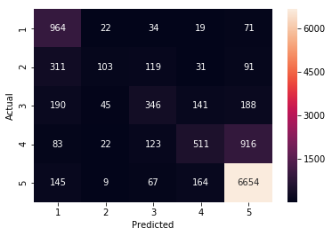

```python
sns.heatmap(cm, annot=True, fmt='d', xticklabels=['1', '2', '3', '4', '5'], yticklabels=['1', '2', '3', '4', '5'])
plt.ylabel('Actual')
plt.xlabel('Predicted')
plt.show()
```

**Classification Report**

```python
print(sklearn.metrics.classification_report((y_valid.argmax(axis=-1)), y_classes,
                                            target_names = ['1', '2', '3', '4', '5']))
```

```
             precision    recall  f1-score   support

          1       0.57      0.87      0.69      1110
          2       0.51      0.16      0.24       655
          3       0.50      0.38      0.43       910
          4       0.59      0.31      0.41      1655
          5       0.84      0.95      0.89      7039

avg / total       0.73      0.75      0.73     11369
```

# Train on the entire training set

Skip unless I open up AWS

[figure not shown]

```python
moo = np.concatenate((x_train, x_valid), axis=0)
print(x_train.shape)
print(x_valid.shape)
print(moo.shape)
```

```python
foo = np.concatenate((y_train, y_valid), axis=0)
print (foo)
```

```python
history_fin = model_lstm.fit(moo, foo, epochs=4, batch_size=128)
```

### Make some Predictions!</h3>

[figure not shown]

```python
# replace with the data you want to classify
newtexts = ["Opened one of these up last night only to find a spider web formed around the bar! Immediately threw it on the floor, as I assumed the spider must still be in there (dead or alive). Thankful I didn't take a bite out of this one. Pretty sure my view on Larabar has changed unfortunately."]
```

```python
def rnn_prediction(review, model, sequences):
    sequences = tokenizer.texts_to_sequences(review)
    data = pad_sequences(sequences, maxlen=1000)
    predictions = model.predict(data)
    results = pd.DataFrame(predictions)
    results.columns = ['1-star', '2-star', '3-star', '4-star', '5-star']
    rframe = pd.DataFrame(predictions)
    rframe.columns = ['1-star', '2-star', '3-star', '4-star', '5-star']
    rframe.index.names = ['Probability']
    rframe.rename(index={0: 'your_review'}, inplace=True)
    (rframe.transpose()).plot(kind='bar')
    plt.show()
```

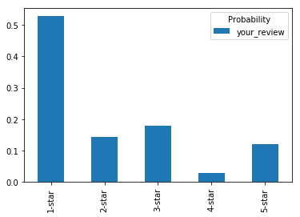

```python
rnn_prediction(newtexts, model_lstm, sequences)
```

[figure not shown]

```python
newtexts = ["Should be called a date bar. I didn't taste any coconut flavor at all, but it says it's made with coconut and coconut oil...and the oil doesn't have much flavor so...yeah. Their is a few pieces of shaved coconut in it, I could feel the texture. Overall, a decent bar...not as 'chunky' as the other lara bars I normally eat (blueberry pie, apple pie), but it was good. Feels 'lighter', not as acidic. So even though I was hoping for a creamy coconut flavored bar (with coconut cream and more coconut flavor), this was still good."]
```

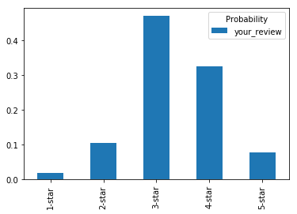

```python
rnn_prediction(newtexts, model_lstm, sequences)
```

[figure not shown]

```python
newtexts=["I really like the flavor of these and enjoy them for breakfast. The only negative is these bars tends to be oily. I always have to wrap a paper towel around it to remove the oil before I eat them. I haven't noticed that with any other flavors. Besides that though, I really like these."]
```

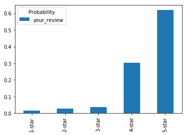

```python
rnn_prediction(newtexts, model_lstm, sequences)
```

[figure not shown]

```python
newtexts=["The Cashew Cookie bars are delicious and Whole30 approved! I've been buying bars from the grocery store then realized I could save money by buying a box of them from Amazon. So I order my box and kept it in my office snack drawer so there was always a healthy midday snack. It's been not even 3 weeks and the bars have MOLD on them! EW EW EW!!! Here's the kicker, the expiration date on them is FEBRUARY 2018(!!) I think that because they are made with fresh, no preservative ingredients, they have a short shelf life. But still, EW!"]
```

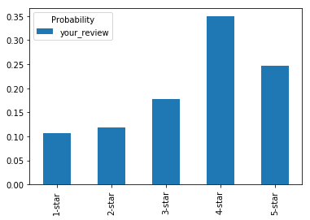

```python
rnn_prediction(newtexts, model_lstm, sequences)
```

[figure not shown]

```python
newtexts=["Honestly, I didn't like these very much. I prefer some of the other flavors instead, like the chocolate chip ones. I didn't get a very peanut butter cookie taste. That doesn't mean others won't, and they were still OKAY, I just won't buy them again personally so long as there are other flavors available."]
```

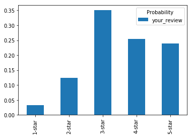

```python
rnn_prediction(newtexts, model_lstm, sequences)
```

[figure not shown]

```python
newtexts=["At a dollar each, these tiny bars are not worth it. They are also high in carbs, so not good for diabetics. I am a blueberry lover, but the taste of these is only mediocre."]
```

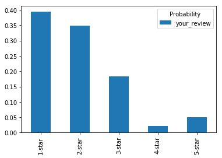

```python
rnn_prediction(newtexts, model_lstm, sequences)
```

[figure not shown]

```python
newtexts=["I love Larabars! I have one for breakfast and one as an afternoon snack every day. They are sweet and help to satisfy my hunger, but they don't weigh me down like a candy bar and aren't filled with chemical crap. Some flavors are better than others. These carrot cake are my favorite. They have a great flavor and a nice texture. I also recommend trying apple pie, mint brownie, and coconut chocolate chip. The cherry pie and coconut cream pie were too sweet for me."]
```

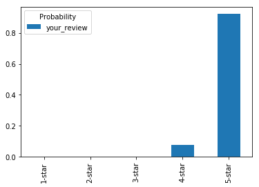

```python
rnn_prediction(newtexts, model_lstm, sequences)
```

# Summary

At the end of this tutorial, we learned a few things. Let's review: 1) Vectorization and "Conventional" Machine Learning Models 2) Ensemble Modeling 3) Deep Learning: CNN vs RNN

If we have time, what ideas do you have to improve the performance of these models?